# Customizing your plots to make that perfect visual

## 5.3 Modifying the legend text

One super annoying part of about is that we see the abbreviation “mfr” as the title of the legend. That’s the name of the column in our spreadsheet, and it’s handy to have it short because, well, less typing. But in a professional visualization, you’ll probably want to spell it out.

You can modify the original data, but it might just be easier to make a superficial change. This can happen in the `scale_color_manual` function again, with the argument `name`.

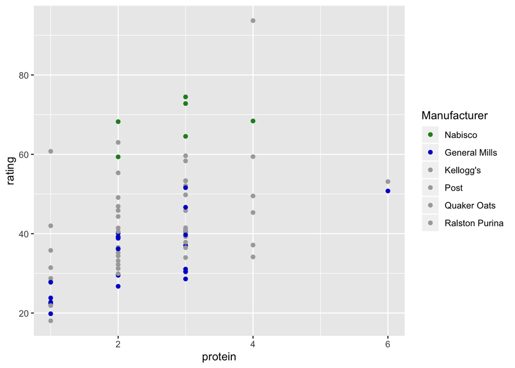

```r
ggplot(cereal_renamed, aes(protein, rating)) +
    geom_point(aes(color = mfr)) +
    scale_color_manual(name = "Manufacturer",
                       values = c("blue3", "darkgrey", "forestgreen",
                                  "darkgrey", "darkgrey", "darkgrey"),
                       breaks = c("Nabisco", "General Mills", "Kellogg's", "Post",
                                  "Quaker Oats", "Ralston Purina"))
```

So now we have three arguments in `scale_color_manual`: `name`, `values`, and `breaks`. The order that they appear makes no difference. But I like to at least put the `name` at the top since it appears at the top in the final plot.

We can also modify the legend labels. We saw how to change the underlying data above in the Renaming and reordering section. But just as you sometimes want to change and order just for the purpose of a single plot, you can rename things superficially while keeping the underlying data intact. To illustrate this, I’ll use the original `cereal` dataset, which has the one-letter abbreviations for the manufacturers, and I’ll change them in the plot (and I’ll make them lowercase to show that they’re different). To accomplish this, I add the `labels` argument to the other three.

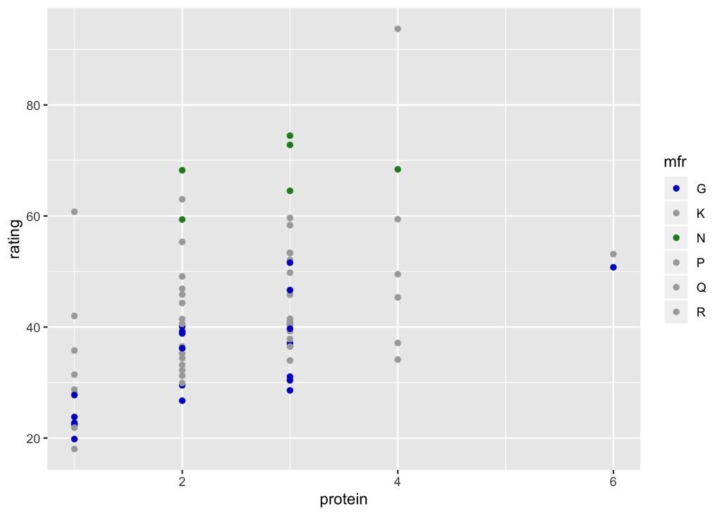

```r
# Plot with no changes to the legend (other than color)
ggplot(cereal, aes(protein, rating)) +
    geom_point(aes(color = mfr)) +
    scale_color_manual(values = c("blue3", "darkgrey", "forestgreen",
                                  "darkgrey", "darkgrey", "darkgrey"))
```

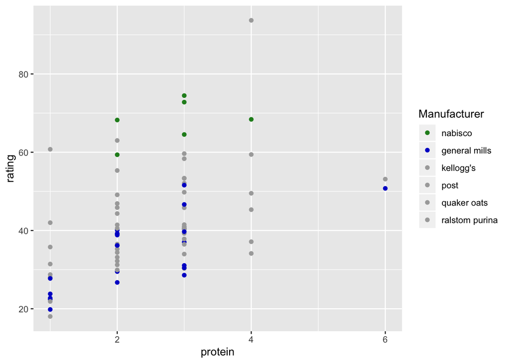

```r
# Plot with all changes in title, order, labels, and colors
ggplot(cereal, aes(protein, rating)) +
    geom_point(aes(color = mfr)) +
    scale_color_manual(name = "Manufacturer",
                       breaks = c("N", "G", "K", "P", "Q", "R"),
                       labels = c("nabisco", "general mills", "kellogg's",
                                  "post", "quaker oats", "ralstom purina"),
                       values = c("blue3", "darkgrey", "forestgreen",
                                  "darkgrey", "darkgrey", "darkgrey"))
```

Thus, with a little bit of typing, you can modify whatever you want with the legend.

### Your turn!

#### The challenge

Everything about manually changing things in the legend in `scale_color_manual` also applies to `scale_fill_manual` and `scale_fill_brewer`. Try making barplot with the original `cereal` dataset but manually modify the name, order, and labels (and colors unless you use Color Brewer). The result should be such that the legend is in your custom order but bars are still in alphabetical order (with one-letter abbreviations underneath). Not a useful plot, but a useful exercise.

#### The solution

I decided to use `scale_fill_brewer`, so I didn’t need to manually set the colors.

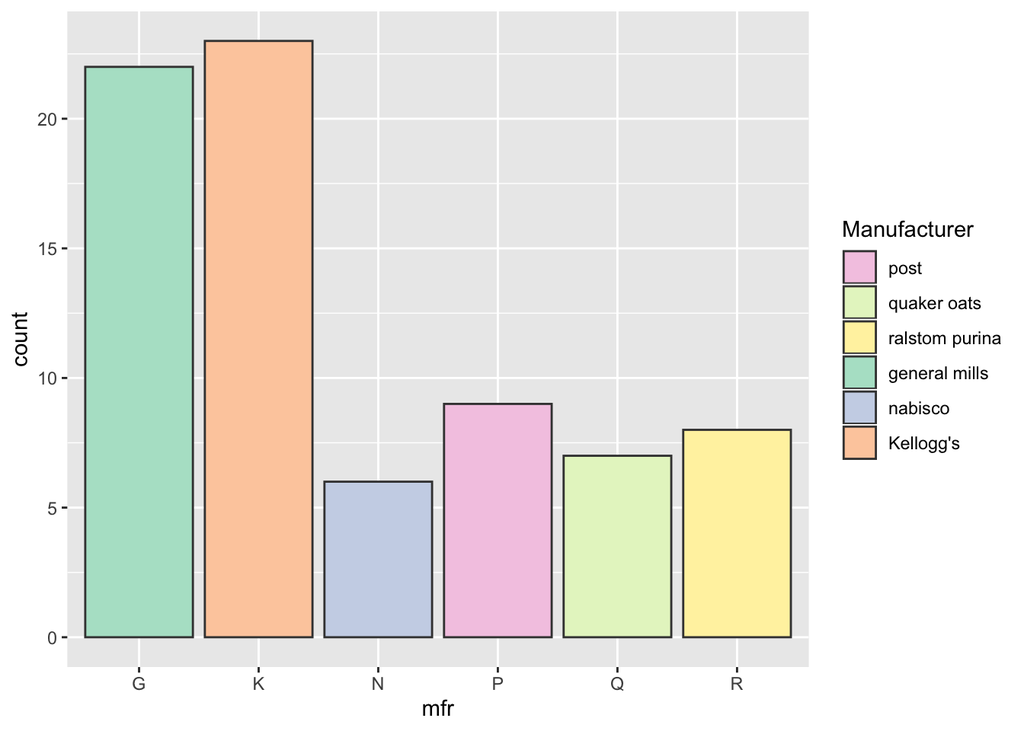

```r
ggplot(cereal, aes(mfr)) +
    geom_bar(aes(fill = mfr), color = "grey25") +
    scale_fill_brewer(type = "qual", palette = "Pastel2",
                      name = "Manufacturer",
                      breaks = c("P", "Q", "R", "G", "N", "K"),
                      labels = c("post", "quaker oats", "ralstom purina",
                                 "general mills", "nabisco", "Kellogg's"))
```

## 5.4 Credit to R Cookbook

Much of the material from this section was borrowed from Winston Chang’s http://www.cookbook-r.com, specifically the page on legends in ggplot2. I refer to this page all the time in my own research, and there’s so much more that is covered there that I couldn’t get to here. Be sure to check it out.

# 6 Final Remarks

I hope this workshop has at least got you interested in using ggplot2. I know there’s a lot to learn, but there are patterns in the code, making it somewhat easy to try new things. Visualizing data is a key component of data analysis: sometimes it’s for your own consumption so that you can understand your own data and sometimes its for public consumption such as in a presentation or a paper. ggplot2 is a very good solution that should solve most people’s needs and with it you can soon be able to create stunning visualizations with your data.

Now that you have two workshops’ experience, you’ve seen that ggplot2 is a workhorse and can do a lot things. In this workshop we saw how to change the big things in your plots (titles, axes, colors, names, orders, legends, facets, themes) and how it’s relatively straightforward to make these changes. With these tools under your belt, you’re on your way to making some really professional-looking visualizations.